# Naive Bayes Classification

Data Mining

Description for Naive Bayes Classification

Yeongeun Jeon , Jung In Seo  
2023-03-23

> Naive Bayes의 장점
- 연속형과 범주형 예측 변수 모두 가능하다.
- 튜닝(Tuning)해야 하는 초모수(Hyperparameter)가 없다.
- Topic 분류 문제에 잘 작동한다.

> Naive Bayes의 단점
- 연속형 예측 변수는 정규 분포를 가정한다.
- 예측 변수들은 서로 독립이어야 한다.

> 실습 자료 : 2004년 1월 한 달간 워싱턴 D.C.에서 출발하여 뉴욕에 도착한 2,201대의 항공편에 대한 자료(출처 : www.transtats.bts.gov)이며, 총 13개의 변수를 포함하고 있다. 13개의 변수 중 분석을 위해 사용할 변수는 `CRS_DEP_TIME`, `CARRIER`, `DEST`, `ORIGIN`, `DAY_WEEK`, `Flight Status`이며, **Target**은 `Flight Status`이다.

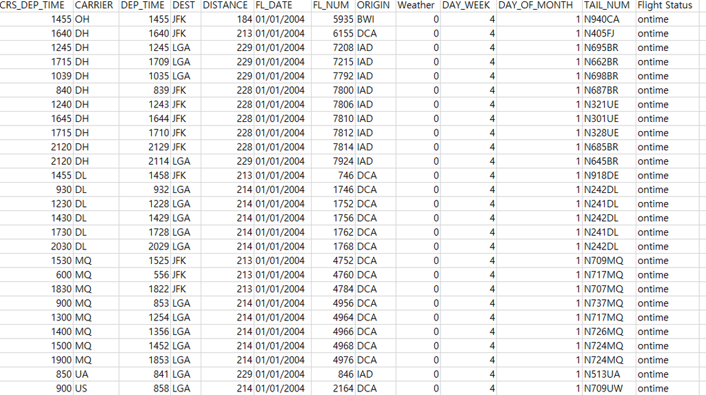

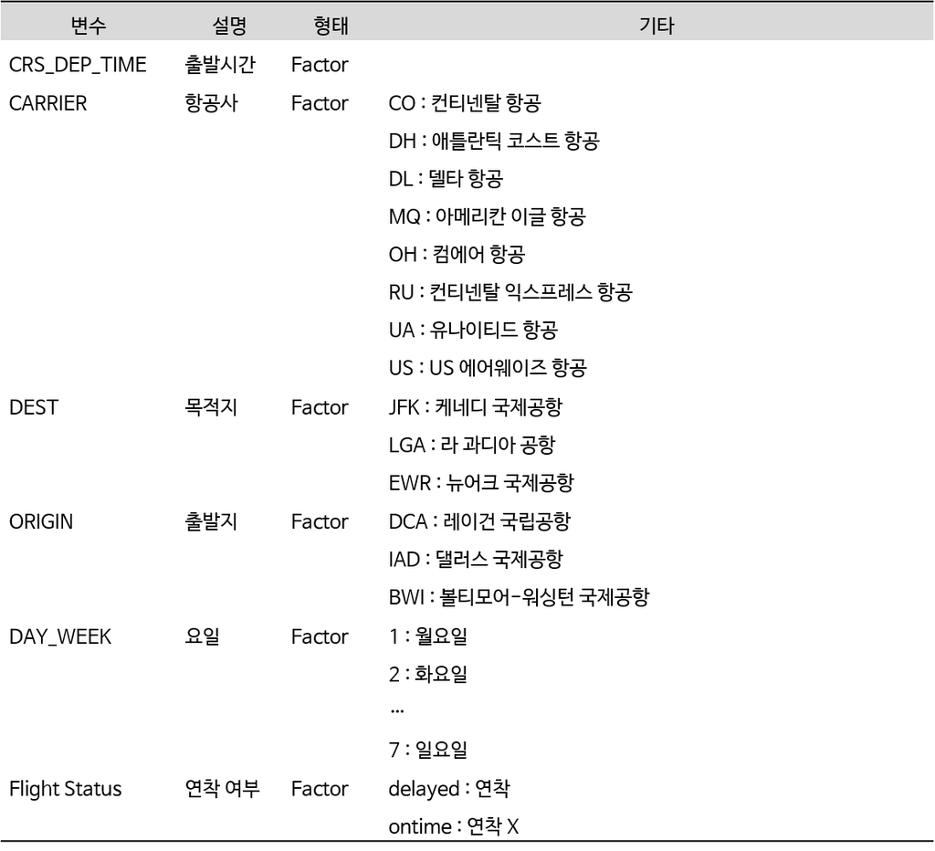

# **1. 데이터 불러오기**

```r
pacman::p_load("data.table",
               "dplyr",  "tidyr", "magrittr",
               "ggplot2",
               "e1071",                                         # For naiveBayes
               "caret")                                         # For confusionMatrix


delays.df <- fread("../FlightDelays.csv")                       # 데이터 불러오기


delays.df %>%
  as_tibble
```

```
# A tibble: 2,201 × 13
   CRS_DEP_TIME CARRIER DEP_TIME DEST  DISTANCE FL_DATE  FL_NUM ORIGIN
          <int> <chr>      <int> <chr>    <int> <chr>     <int> <chr>
 1         1455 OH          1455 JFK        184 01/01/2…   5935 BWI
 2         1640 DH          1640 JFK        213 01/01/2…   6155 DCA
 3         1245 DH          1245 LGA        229 01/01/2…   7208 IAD
 4         1715 DH          1709 LGA        229 01/01/2…   7215 IAD
 5         1039 DH          1035 LGA        229 01/01/2…   7792 IAD
 6          840 DH           839 JFK        228 01/01/2…   7800 IAD
 7         1240 DH          1243 JFK        228 01/01/2…   7806 IAD
 8         1645 DH          1644 JFK        228 01/01/2…   7810 IAD
 9         1715 DH          1710 JFK        228 01/01/2…   7812 IAD
10         2120 DH          2129 JFK        228 01/01/2…   7814 IAD
# ℹ 2,191 more rows
# ℹ 5 more variables: Weather <int>, DAY_WEEK <int>,
#   DAY_OF_MONTH <int>, TAIL_NUM <chr>, `Flight Status` <chr>
```

# **2. 데이터 전처리**

- 전처리는 2단계의 과정을 거친다.
  1. 출발시간(CRS_DEP_TIME)을 시간 단위(Hourly)로 변환한다.
     - 예를 들어, `1455`이면 `14시 55분`을 의미하며, 이것을 `14`로 변환한다.
  2. 범주형 변수들을 범주형으로 변환한다.

```r
# 1. 출발시간(CRS_DEP_TIME)을 시간 단위(hourly)로 변환
# 예) 출발시간이 오전 6시와 오전 7시 사이라면, CRS_DEP_TIME = 6
delays.df %<>%
  data.frame() %>%                                                      # Data Frame 형태로 변환
  mutate(CRS_DEP_TIME = floor( CRS_DEP_TIME/100 ))

# 2. Convert to Factor
selected.var <- c("CRS_DEP_TIME", "CARRIER", "DEST",                    # 범주형 변수 선택
                  "ORIGIN", "DAY_WEEK", "Flight.Status")

delays.df %<>%
  mutate_at(selected.var, as.factor)                                    # 범주형으로 변환

# 3. Select Variables used for Analysis
delays.df1 <- delays.df %>%
  select(selected.var)                                                  # 분석에 사용할 변수만 선택

delays.df1 %>%
  as_tibble
```

```
# A tibble: 2,201 × 6
   CRS_DEP_TIME CARRIER DEST  ORIGIN DAY_WEEK Flight.Status
   <fct>        <fct>   <fct> <fct>  <fct>    <fct>
 1 14           OH      JFK   BWI    4        ontime
 2 16           DH      JFK   DCA    4        ontime
 3 12           DH      LGA   IAD    4        ontime
 4 17           DH      LGA   IAD    4        ontime
 5 10           DH      LGA   IAD    4        ontime
 6 8            DH      JFK   IAD    4        ontime
 7 12           DH      JFK   IAD    4        ontime
 8 16           DH      JFK   IAD    4        ontime
 9 17           DH      JFK   IAD    4        ontime
10 21           DH      JFK   IAD    4        ontime
# ℹ 2,191 more rows
```

```r
glimpse(delays.df1)                                                     # 데이터 구조 확인
```

```
Rows: 2,201
Columns: 6
$ CRS_DEP_TIME  <fct> 14, 16, 12, 17, 10, 8, 12, 16, 17, 21, 21, 14,…
$ CARRIER       <fct> OH, DH, DH, DH, DH, DH, DH, DH, DH, DH, DH, DL…
$ DEST          <fct> JFK, JFK, LGA, LGA, LGA, JFK, JFK, JFK, JFK, J…
$ ORIGIN        <fct> BWI, DCA, IAD, IAD, IAD, IAD, IAD, IAD, IAD, I…
$ DAY_WEEK      <fct> 4, 4, 4, 4, 4, 4, 4, 4, 4, 4, 4, 4, 4, 4, 4, 4…
$ Flight.Status <fct> ontime, ontime, ontime, ontime, ontime, ontime…
```

# **3. 데이터 탐색**

```r
# 데이터 구조 변환
visual.df <- pivot_longer(delays.df1,
                          cols = -Flight.Status,          # Target 제외
                          names_to = "Variables",         # 변수 이름이 입력될 새로운 열 이름
                          values_to = "values"            # 변수에 입력된 값에 대한 새로운 열 이름
                          )

visual.df
```

```
# A tibble: 11,005 × 3
   Flight.Status Variables    values
   <fct>         <chr>        <fct>
 1 ontime        CRS_DEP_TIME 14
 2 ontime        CARRIER      OH
 3 ontime        DEST         JFK
 4 ontime        ORIGIN       BWI
 5 ontime        DAY_WEEK     4
 6 ontime        CRS_DEP_TIME 16
 7 ontime        CARRIER      DH
 8 ontime        DEST         JFK
 9 ontime        ORIGIN       DCA
10 ontime        DAY_WEEK     4
# ℹ 10,995 more rows
```

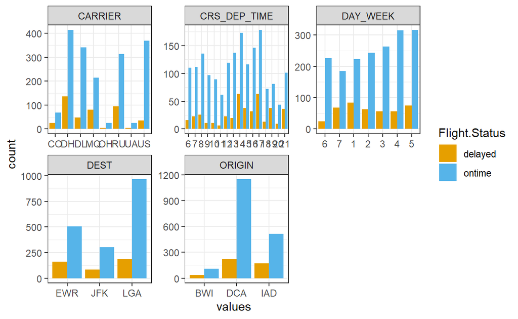

```r
ggplot(visual.df, aes(values, fill = Flight.Status)) +
  facet_wrap(~ Variables, scales = "free") +
  geom_bar(position = "dodge") +
  scale_fill_manual(values=c("#E69F00", "#56B4E9")) +     # 막대 색깔 지정
  theme_bw()
```

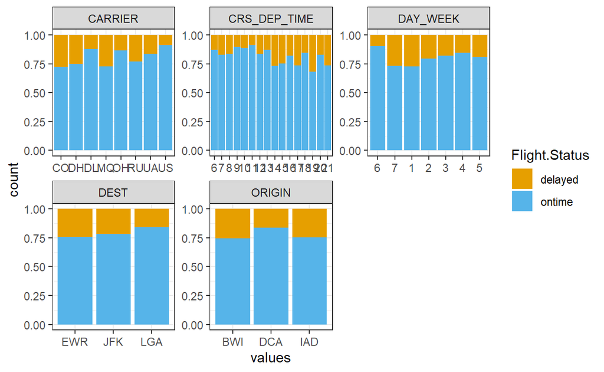

```r
ggplot(visual.df, aes(values, fill = Flight.Status)) +
  facet_wrap(~ Variables, scales = "free") +
  geom_bar(position = "fill") +
  scale_fill_manual(values=c("#E69F00", "#56B4E9")) +     # 막대 색깔 지정
  theme_bw()
```

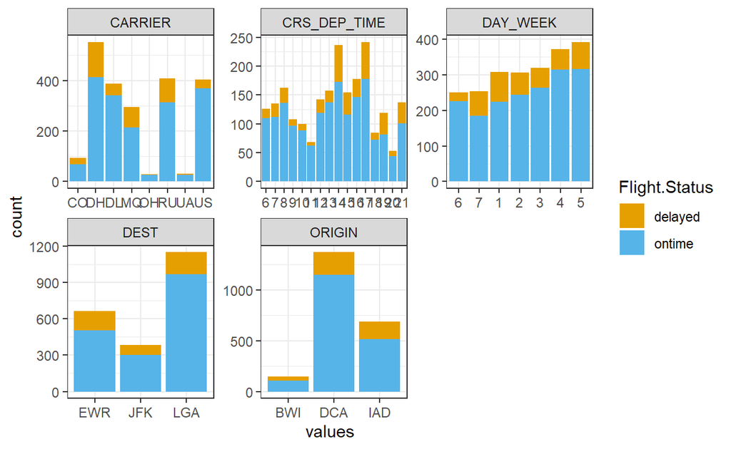

```r
ggplot(visual.df, aes(values, fill = Flight.Status)) +
  facet_wrap(~ Variables, scales = "free") +
  geom_bar(position = "stack") +
  scale_fill_manual(values=c("#E69F00", "#56B4E9")) +     # 막대 색깔 지정
  theme_bw()
```

# **4. 데이터 분할**

```r
# Partition (Training Dataset : Test Dataset = 7:3)
y <- delays.df1$Flight.Status                                           # Target

set.seed(200)
ind         <- createDataPartition(y, p = 0.7, list = T)                # Index를 이용하여 7:3으로 분할
delays.trd  <- delays.df1[ind$Resample1, ]                              # Training Dataset
delays.ted  <- delays.df1[-ind$Resample1, ]                             # Test Dataset
```

# **5. 모형 훈련**

> 함수 `naiveBayes`를 이용하여 Naive Bayes를 수행할 수 있다. 함수에서 사용할 수 있는 자세한 옵션은 [여기](https://www.rdocumentation.org/packages/e1071/versions/1.7-13/topics/naiveBayes)를 참고한다.

```r
naiveBayes(formula, data, laplace = 0, ...)
```

- `formula` : Target과 예측 변수의 관계를 표현하기 위한 함수로써 일반적으로 `Target ~ 예측 변수`의 형태로 표현한다.
- `data` : `formula`에 포함된 변수들의 데이터셋
- `laplace` : 라플라스 스무딩(Laplace Smoothing)을 위한 가중치 $\alpha$
  - 범주형 예측 변수에 대해 사건 발생 가능성이 매우 희박하여 우도가 0이 되는 경우를 방지하기 위해 사용하는 옵션
  - 예를 들어, 스팸 메일 분류(나이브 베이즈 PPT, p.7)에서 스팸 메일 중 “비아그라 단어가 포함”된 메일이 있을 확률, 즉, 우도 $P(\text{비아그라 포함}|\text{스팸})$에 라플라스 스무딩을 적용하면 다음과 같다.
    $$\begin{align*}
    P(\text{비아그라 포함}|\text{스팸})=\frac{\text{비아그라가 포함된 스팸 메일 수}+\alpha}{\text{전체 스팸 메일 수} + k\times \alpha}
    \end{align*}$$
    - $k$ : 범주형 예측 변수의 class 개수로 해당 예제에서는 “비아그라 포함 O/비아그라 포함 X”로 $k=2$이다.

```r
delays.nb <- naiveBayes(Flight.Status ~ .,                              # Target ~ 예측 변수
                        data = delays.trd)
delays.nb
```

```
Naive Bayes Classifier for Discrete Predictors

Call:
naiveBayes.default(x = X, y = Y, laplace = laplace)

A-priori probabilities:
Y
  delayed    ontime
0.1945525 0.8054475

Conditional probabilities:
         CRS_DEP_TIME
Y                  6          7          8          9         10
  delayed 0.02666667 0.04666667 0.07000000 0.02666667 0.01666667
  ontime  0.06682770 0.06521739 0.06924316 0.06199678 0.04991948
         CRS_DEP_TIME
Y                 11         12         13         14         15
  delayed 0.01666667 0.04333333 0.05333333 0.17000000 0.07000000
  ontime  0.03623188 0.06280193 0.07568438 0.09581320 0.06682770
         CRS_DEP_TIME
Y                 16         17         18         19         20
  delayed 0.08333333 0.15666667 0.03000000 0.07666667 0.02333333
  ontime  0.08132045 0.10064412 0.04508857 0.04186795 0.02415459
         CRS_DEP_TIME
Y                 21
  delayed 0.09000000
  ontime  0.05636071

         CARRIER
Y                 CO         DH         DL         MQ         OH
  delayed 0.07666667 0.32000000 0.11666667 0.18000000 0.01333333
  ontime  0.03542673 0.23349436 0.17632850 0.12962963 0.01529791
         CARRIER
Y                 RU         UA         US
  delayed 0.19333333 0.01333333 0.08666667
  ontime  0.18115942 0.01368760 0.21497585

         DEST
Y               EWR       JFK       LGA
  delayed 0.3766667 0.2100000 0.4133333
  ontime  0.2882448 0.1723027 0.5394525

         ORIGIN
Y                BWI        DCA        IAD
  delayed 0.07666667 0.52666667 0.39666667
  ontime  0.06280193 0.64492754 0.29227053

         DAY_WEEK
Y                 1         2         3         4         5         6
  delayed 0.1900000 0.1500000 0.1166667 0.1466667 0.1766667 0.0600000
  ontime  0.1264090 0.1336554 0.1545894 0.1876006 0.1626409 0.1336554
         DAY_WEEK
Y                 7
  delayed 0.1600000
  ontime  0.1014493
```

`Result!` 첫 번째 Table `A-priori probabilities`는 Target $Y$의 각 class에 대한 사전확률 $P(Y=y)$이고, 두 번째 Table `Conditional probabilities`는 예측 변수 $X$가 범주형일 때는 $P(X|Y)$를 나타내며, 연속형일 때는 평균과 표준편차를 나타낸다.

# **6. 모형 평가**

`Caution!` 모형 평가를 위해 `Test Dataset`에 대한 `예측 class/확률` 이 필요하며, 함수 `predict()`를 이용하여 생성한다.

```r
# 예측 class 생성
pred.class <- predict(delays.nb,
                      newdata = delays.ted[,-6])         # 함수 predict에서는 Target 제외

# 예측 확률( 사후확률 P(Y|X) ) 생성
pred.prob  <- predict(delays.nb,
                      newdata = delays.ted[,-6],         # 함수 predict에서는 Target 제외
                      type = "raw")

# Test Dataset의 실제값과 예측 결과
df <- data.frame(actual = delays.ted$Flight.Status,
                 pred.class = pred.class, pred.prob)
df %>%
  as_tibble
```

```
# A tibble: 659 × 4
   actual pred.class delayed ontime
   <fct>  <fct>        <dbl>  <dbl>
 1 ontime ontime      0.303   0.697
 2 ontime ontime      0.302   0.698
 3 ontime ontime      0.0325  0.967
 4 ontime ontime      0.122   0.878
 5 ontime ontime      0.0702  0.930
 6 ontime ontime      0.162   0.838
 7 ontime ontime      0.0690  0.931
 8 ontime ontime      0.0969  0.903
 9 ontime ontime      0.187   0.813
10 ontime ontime      0.241   0.759
# ℹ 649 more rows
```

```r
# 일요일 오전 10시와 오전 11시 사이에 DCA (레이건 국립공항)에서 LGA (라 과디아 공항)로 가는 DL (델타 항공)의 연착 여부 예측 결과
df[delays.ted$DAY_WEEK == 7 & delays.ted$CRS_DEP_TIME == 10 & delays.ted$ORIGIN == "DCA" &
   delays.ted$DEST == "LGA" & delays.ted$CARRIER == "DL",]
```

```
    actual pred.class    delayed    ontime
215 ontime     ontime 0.05002181 0.9499782
```

## **6-1. ConfusionMatrix**

```r
CM <- caret::confusionMatrix(pred.class, delays.ted$Flight.Status,
                             positive = "delayed")            # confusionMatrix(예측 class, 실제 class, positive = "관심 class")
CM
```

```
Confusion Matrix and Statistics

          Reference
Prediction delayed ontime
   delayed      12     21
   ontime      116    510

               Accuracy : 0.7921
                 95% CI : (0.7591, 0.8225)
    No Information Rate : 0.8058
    P-Value [Acc > NIR] : 0.8256

                  Kappa : 0.0755

 Mcnemar's Test P-Value : 9.671e-16

            Sensitivity : 0.09375
            Specificity : 0.96045
         Pos Pred Value : 0.36364
         Neg Pred Value : 0.81470
             Prevalence : 0.19423
         Detection Rate : 0.01821
   Detection Prevalence : 0.05008
      Balanced Accuracy : 0.52710

       'Positive' Class : delayed
```

## **6-2. ROC 곡선**

```r
# 예측 확률( 사후확률 P(Y|X) )
pred.prob %>%
  as_tibble
```

```
# A tibble: 659 × 2
   delayed ontime
     <dbl>  <dbl>
 1  0.303   0.697
 2  0.302   0.698
 3  0.0325  0.967
 4  0.122   0.878
 5  0.0702  0.930
 6  0.162   0.838
 7  0.0690  0.931
 8  0.0969  0.903
 9  0.187   0.813
10  0.241   0.759
# ℹ 649 more rows
```

```r
delayed.pred.prob <- pred.prob[,1]                            # "Flight.Status = delayed"에 대한 예측 확률

ac <- ifelse(delays.ted$Flight.Status == "delayed", 1, 0)     # 실제 class를 수치형으로 변환
pp <- as.numeric(delayed.pred.prob)                           # 예측 확률을 수치형으로 변환
```

### **1) Package “pROC”**

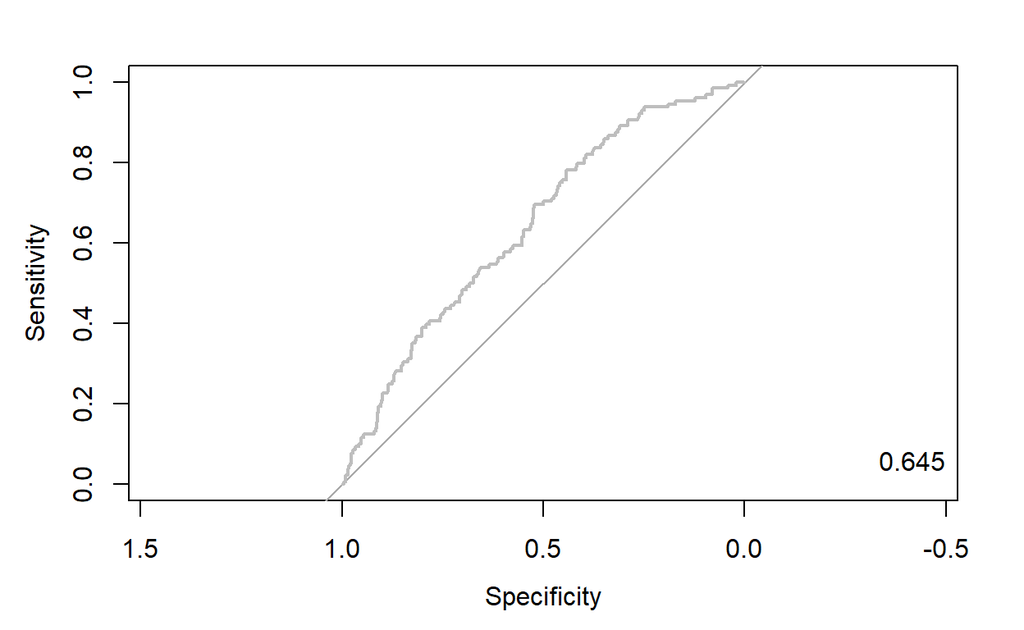

```r
pacman::p_load("pROC")

nb.roc  <- roc(ac, pp, plot = T, col = "gray")                # roc(실제 class, 예측 확률)
auc     <- round(auc(nb.roc), 3)
legend("bottomright", legend = auc, bty = "n")
```

`Caution!` Package `"pROC"`를 통해 출력한 ROC 곡선은 다양한 함수를 이용해서 그래프를 수정할 수 있다.

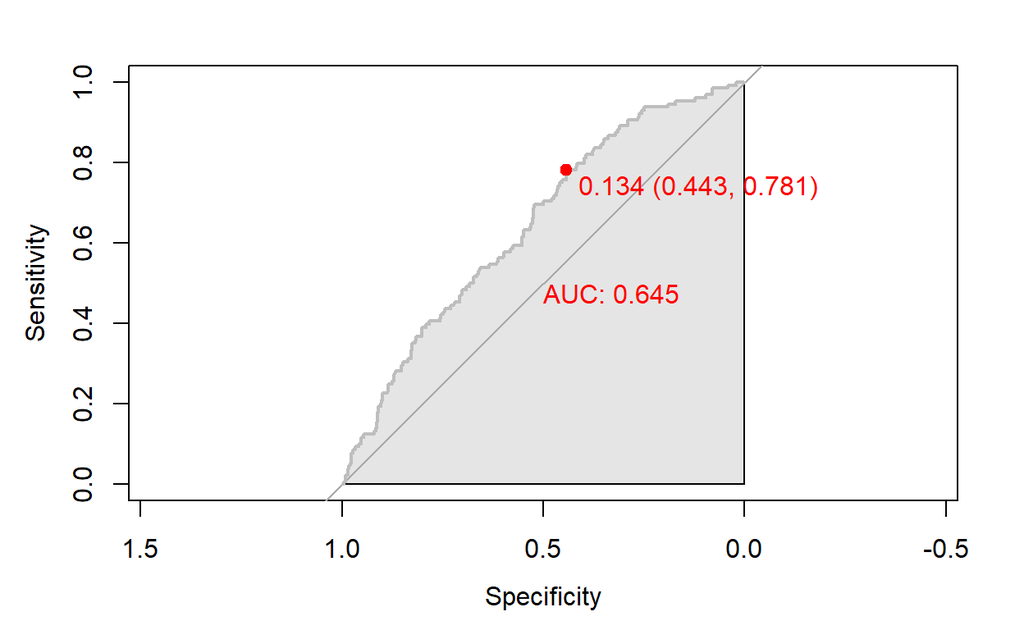

```r
# 함수 plot.roc() 이용
plot.roc(nb.roc,
         col="gray",                                          # Line Color
         print.auc = TRUE,                                    # AUC 출력 여부
         print.auc.col = "red",                               # AUC 글씨 색깔
         print.thres = TRUE,                                  # Cutoff Value 출력 여부
         print.thres.pch = 19,                                # Cutoff Value를 표시하는 도형 모양
         print.thres.col = "red",                             # Cutoff Value를 표시하는 도형의 색깔
         auc.polygon = TRUE,                                  # 곡선 아래 면적에 대한 여부
         auc.polygon.col = "gray90")                          # 곡선 아래 면적의 색깔
```

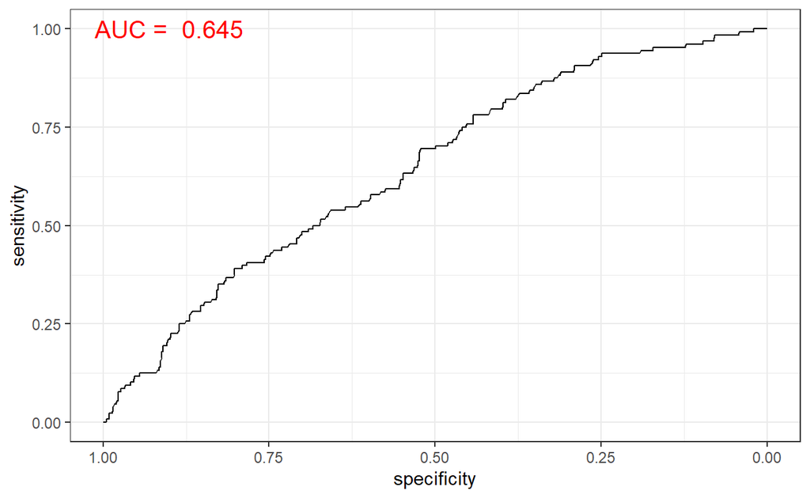

```r
# 함수 ggroc() 이용
ggroc(nb.roc) +
annotate(geom = "text", x = 0.9, y = 1.0,
label = paste("AUC = ", auc),
size = 5,
color="red") +
theme_bw()
```

### **2) Package “Epi”**

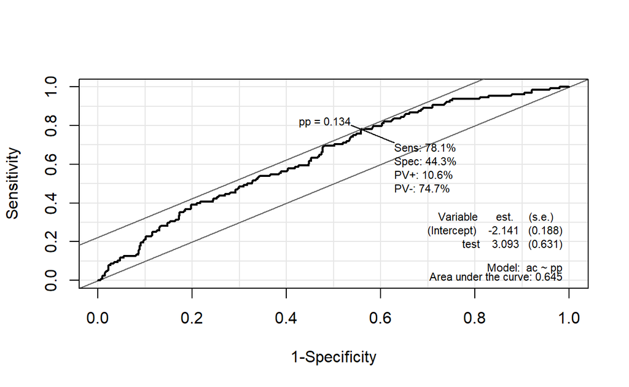

```r
pacman::p_load("Epi")
# install_version("etm", version = "1.1", repos = "http://cran.us.r-project.org")

ROC(pp, ac, plot = "ROC")                                     # ROC(예측 확률, 실제 class)
```

### **3) Package “ROCR”**

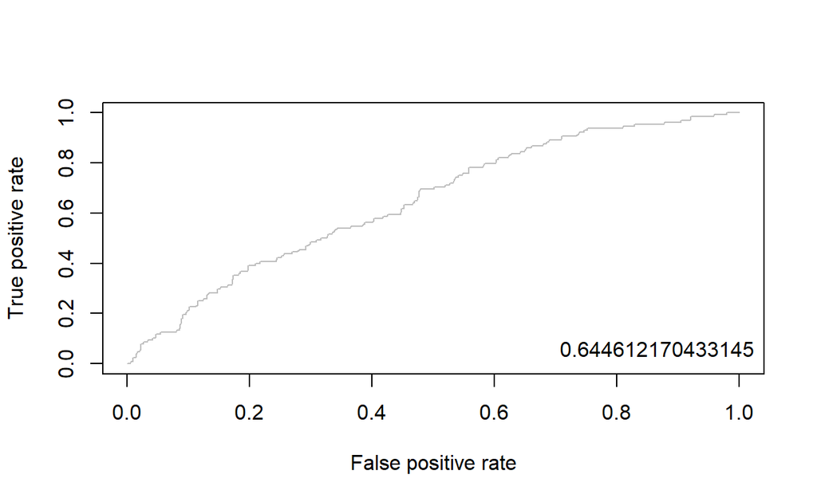

```r
pacman::p_load("ROCR")

pred <- prediction(pp, ac)                                    # prediction(예측 확률, 실제 class)

perf <- performance(pred, "tpr", "fpr")                       # performance(, "민감도", "1-특이도")
plot(perf, col = "gray")                                      # ROC Curve

perf.auc   <- performance(pred, "auc")                        # AUC
auc        <- attributes(perf.auc)$y.values
legend("bottomright", legend = auc, bty = "n")
```

## **6-3. 향상 차트**

### **1) Package “ROCR”**

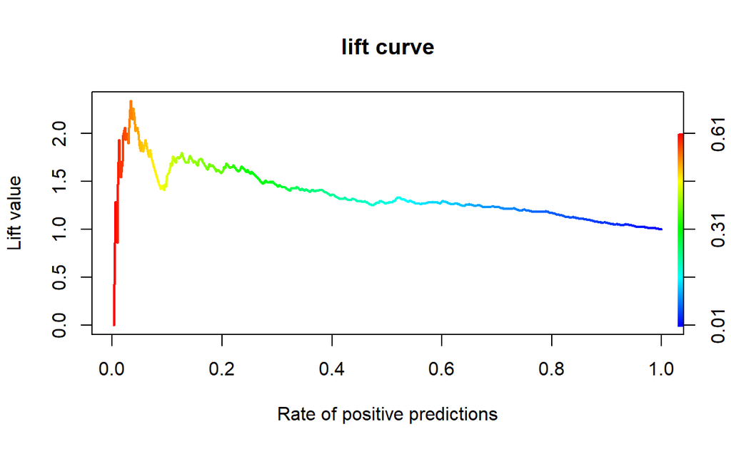

```r
# 향상 차트(Curve)
perf <- performance(pred, "lift", "rpp")       # Lift Chart
plot(perf, main = "lift curve",
     colorize = T,                             # Coloring according to cutoff
     lwd = 2)
```

### **2) Package “gains”**

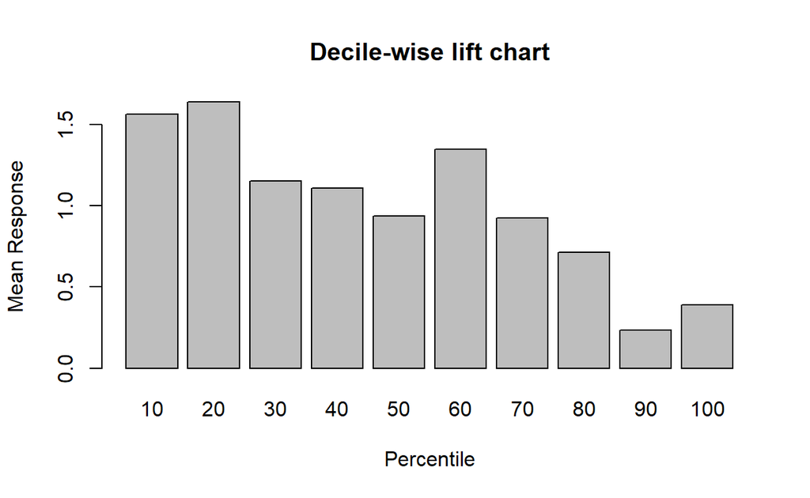

```r
# 향상 차트(십분위)
pacman::p_load("gains")

gain <- gains(ac, pp)                           # gains(실제 class, 예측 확률)

barplot(gain$mean.resp / mean(ac),
        names.arg = gain$depth,
        xlab = "Percentile",
        ylab = "Mean Response",
        main = "Decile-wise lift chart")
```